# Reanalysis of a random medical paper

Recreating some results from publication:

https://doi.org/10.1038/s41598-018-27482-2

The data set contains mortality of patients after burning damage to lung tissue depending on whether and where they had inhalation burns  
first create a new variable that is a factor (0=normal, 1=subjective, 2=upper, and 3=lower) create a data frame for a barplot group by the new inhalation severity variable and the PFdivide (“We also divided the patients into four groups depending on the PF ratio (>300, 200-300, 100-200, and <100)”) you will need the mean and sd of mortality (look out for spelling mistake) for each level of inhalation injury (INHdiv) from this calculate the upper (ymax) and lower (ymin) bounds of the error bars (S.E.M.:mean +- sd/sqrt(n)) create a barplot from this with mean mortality on y axis and Pfdivide on x axis create a facet for each severity level add error bars make nice axis labels

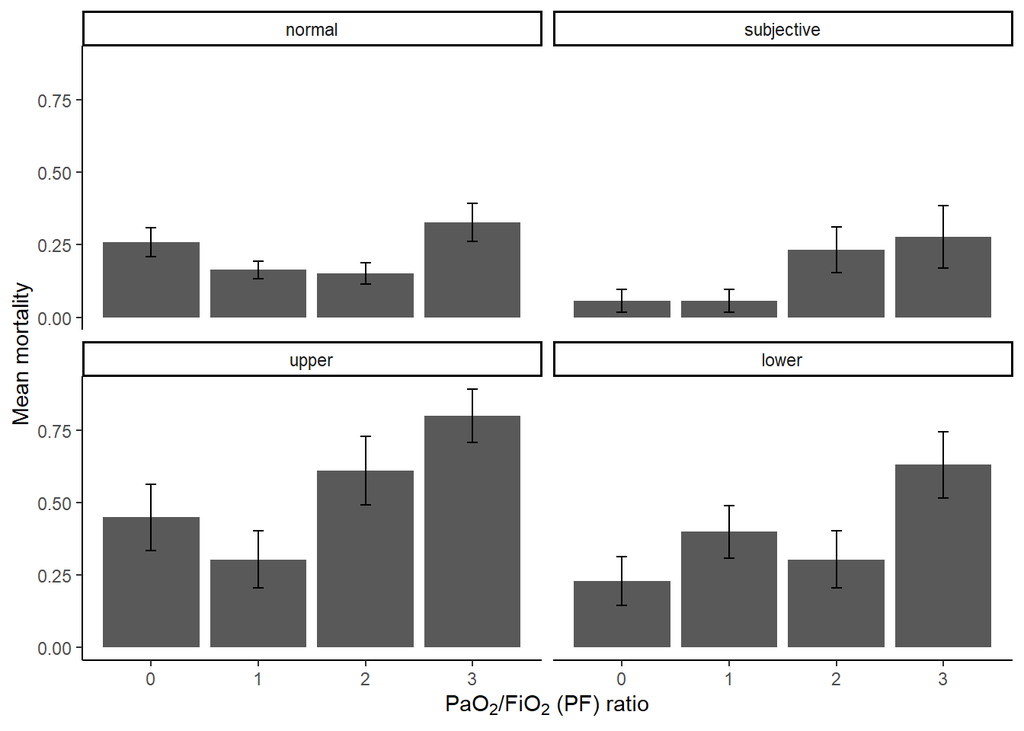

```r
my_data<-
  my_data %>%
  mutate(INHdiv_fac=factor(INHdiv,labels=c("normal","subjective","upper","lower")))
plot_data<-
  my_data %>%
  group_by(INHdiv_fac,Pfdivide) %>%
  summarise(mean_mort=mean(mortaltiy),
            sd_mort=sd(mortaltiy),
            sem_mort=sd_mort/sqrt(n()),
            ymax=mean_mort+sem_mort,
            ymin=mean_mort-sem_mort)
p.1<-ggplot(aes(y=mean_mort,x=Pfdivide),data=plot_data)+geom_bar(stat="identity")+
  geom_errorbar(aes(ymax=ymax,ymin=ymin),width=.1)+
  facet_wrap(~INHdiv_fac)+
  theme_classic()+
  ylab("Mean mortality")+
  xlab(expression("PaO"[2]*"/FiO"[2]*" (PF) ratio"))
p.1
```

We want to do a standard logistic regression on mortality and whether this depends on the PF Ratio:  
PaO2/FiO2 ratio is the ratio of arterial oxygen partial pressure to fractional inspired oxygen.  
It is a widely used clinical indicator of hypoxaemia, though its diagnostic utility is disputed.  
At sea level normal is > 500mmHg.

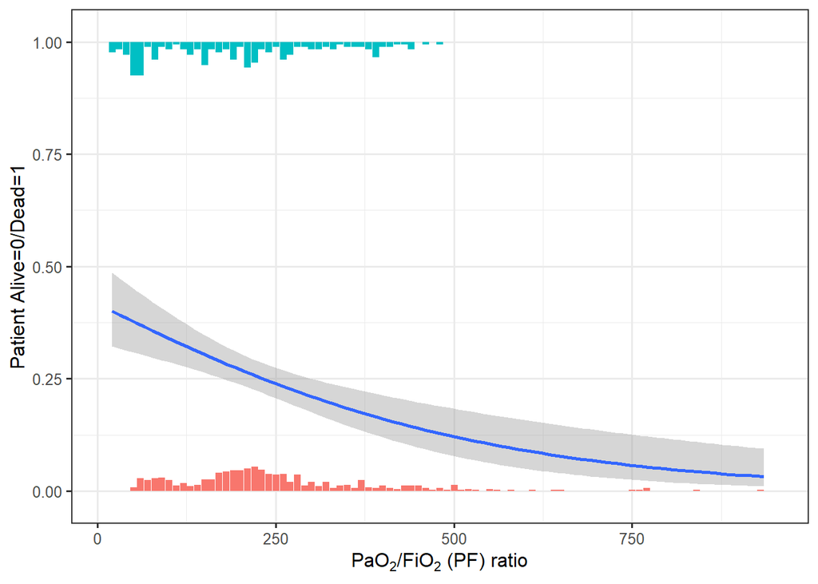

```r
names(my_data)[8]<-c("PFratio")
hist_data<-
  my_data %>%
  #first add new variable that codes breaks
  mutate(breaks = findInterval(PFratio, seq(20,935,10))) %>%
  #then group by dead/alive and the breaks
  group_by(mortaltiy, breaks) %>%
  #count
  summarise(n = n()) %>%
  #if patients are dead, we want them to show on top with histogram on top so you need to
  #calculate in this case the percentage as 1-percentage
  mutate(pct = ifelse(mortaltiy==0, n/sum(n), 1 - n/sum(n)),breaks=seq(20,935,10)[breaks])
######
#
#####
ggplot() + #this just sets an empty frame to build upon
  #first add a histopgram with geom_segment use the help of geom_segment
  geom_segment(data=hist_data, size=2, show.legend=FALSE,
               aes(x=breaks, xend=breaks, y=mortaltiy, yend=pct, colour=factor(mortaltiy)))+
  #then predict a logistic regression via stat_smooth and the glm method (we will cover the details in the next session)
  stat_smooth(data=my_data,aes(y=mortaltiy,x=PFratio),method="glm", method.args = list(family = "binomial"))+
  #some cosmetics
  scale_y_continuous(limits=c(-0.02,1.02)) +
  scale_x_continuous(limits=c(10,950)) +
  theme_bw(base_size=12)+
  ylab("Patient Alive=0/Dead=1")+xlab(expression("PaO"[2]*"/FiO"[2]*" (PF) ratio"))
```

And now we plot this for each severity level separately.

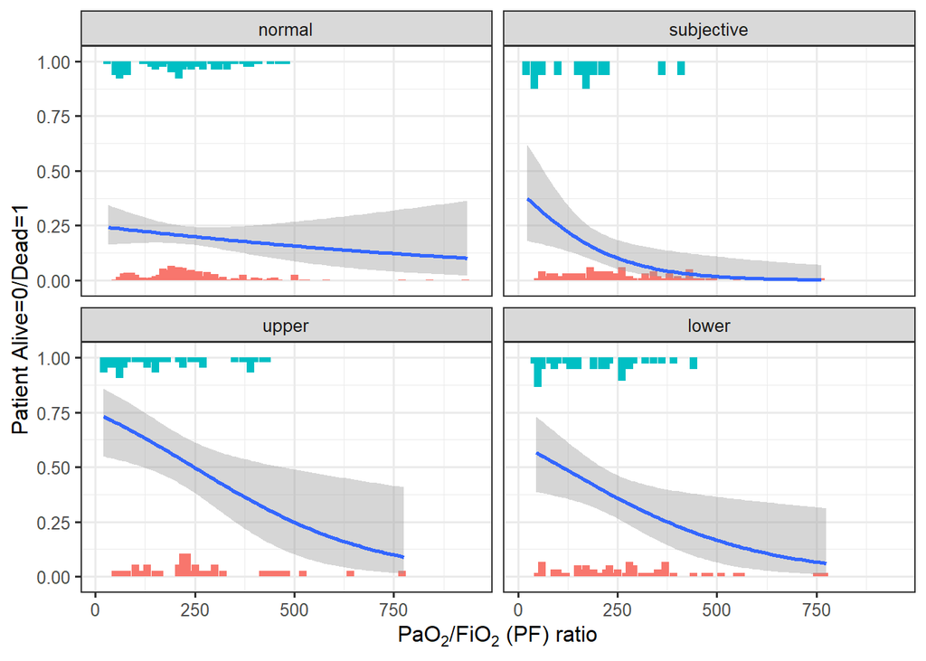

```r
hist_data<-
  my_data %>%
  #first add new variable that codes breaks
  mutate(breaks = findInterval(PFratio, seq(20,935,10))) %>%
  #then group by dead/alive and the breaks
  group_by(INHdiv_fac,mortaltiy, breaks) %>%
  #count
  summarise(n = n()) %>%
  #if patients are dead, we want them to show on top with histogram on top so you need to
  #calculate in this case the percentage as 1-percentage
  mutate(pct = ifelse(mortaltiy==0, n/sum(n), 1 - n/sum(n)),breaks=seq(20,935,10)[breaks])
######
#
#####
ggplot() + #this just sets an empty frame to build upon
  facet_wrap(~INHdiv_fac)+
  #first add a histopgram with geom_segment use the help of geom_segment
  geom_segment(data=hist_data, size=2, show.legend=FALSE,
               aes(x=breaks, xend=breaks, y=mortaltiy, yend=pct, colour=factor(mortaltiy)))+
  #then predict a logistic regression via stat_smooth and the glm method
  #(we will cover the details in the next session)
  stat_smooth(data=my_data,aes(y=mortaltiy,x=PFratio),method="glm", method.args = list(family = "binomial"))+
  #some cosmetics
  scale_y_continuous(limits=c(-0.02,1.02)) +
  scale_x_continuous(limits=c(10,950)) +
  theme_bw(base_size=12)+
  ylab("Patient Alive=0/Dead=1")+xlab(expression("PaO"[2]*"/FiO"[2]*" (PF) ratio"))
```